# A study into Dementia and its surrounding factors

Examination number: Y3868011

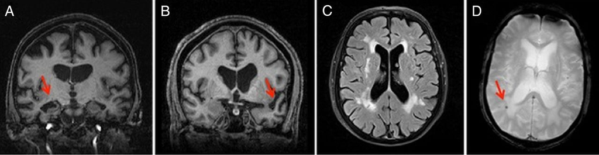

(Bonifacio and Zamboni 2016) (https://pmj.bmj.com/content/92/1088/333)

# 1 Introduction

Dementia is a syndrome and includes many different neurodegenerative brain disorders, triggered by disease of the brain and causing loss of brain function (Dening and Sandilyan 2015). 1 in 6 people over the age of 80 have dementia, which currently there is no cure for. Symptoms of dementia vary from physical to behavioral, including agitation and depression, as well as the well known symptoms being depleting memory and cognitive function (Cerejeira, Lagarto, and Mukaetova-Ladinska 2012; Shih et al. 2014). Researchers are interested in the differences between demented and non-demented individuals, which is where the data being used in this report stems from. The data being analyzed includes subjects with or without dementia, and also subjects who developed dementia through the course of the study. The objective of my analysis hopes to group and tidy the data gathered from the research done on these subjects. The analysis is done through **R** (R Core Team 2020) and presented using **R markdown** with a html output (Allaire et al. 2020).

# 2 Methods

## 2.1 Data Description

There are two separate CSV files: patient_data_raw.csv and visit_data_raw.csv.

Each row is a subject and data from their individual visit. There are two data files and the column descriptions are as follows:

**Patient**

- Subject ID
- Group (demented, nondementded, converted)
  - demented subjects are demented throughout the study, as for nondemented. Subjects who were nondemented on their first visit and demented on following visits are characterized as converted
- m_f indicates gender
- educ states the years of education of the subject
- ses is the ‘socioeconomic status’ as assessed by the Hollingshead Index of Social Position
  - This is classified into categories from 1 (highest status) to 5 (lowest status)

**Visit**

- Subject ID
- MRI number
- Visit indicates the number if visit
- Age
- mmse is the Mini-Mental State Examination score (0 = worst to 30 = best)
- cdr indicates the clinical dementia rating
  - 0 = no dementia, 0.5 = very mild Alzheimers disease, 1 = mild Alzheimers disease, 2 = moderate Alzheimers disease
- etiv is the estimated total intacranial volume measured in mm<sup>3</sup>
- nwbv is the normalized whole-brain volume, expressed as a percent of all voxels in the atlas-masked image that are labeled as gray or white matter by the automated tissue segmentation process
- asf is the Atlas scaling factor (unitless). It is a computed scaling factor which transforms native-space brain and skull to the atlas target

## 2.2 Data preparation and tidying

The raw data was imported into **R** (R Core Team 2020) where it was tidied, filtered using the **tidyverse** package (Wickham 2019), and combined using the **dplyr** package (Wickham et al. 2020) into a new data set, ‘data’. Data from the ‘visit’ data set was filtered out for `mri_numer` as it held the same information as the `visit` column, which was preferred to be the kept column as it is numerical so posed as a better variable for future analysis through PCA and other visualizations.

## 2.3 Pairwise Plot Matrix

Firstly, given that there are 12 variables (9 being numeric), a Pairwise Plot Matrix will be carried out to look at correlations between the variables. This requires using the **GGally** package (Schloerke et al. 2020) and the GGally::ggpairs() function. The non-numeric variables will be excluded except for the ‘group’ variable indicating the dementia status of the subject, which will be shown through different colours. This can give an indication on relationships between variables and between the different grouping classes, and if there is any clustering.

## 2.4 Visualisation using Principal Components Analysis (PCA)

Principal Component Analysis was done on this data to summarize how the variables relate to one another, whilst also providing visualization of the multivariate dataset, identifying variables which can be considered as having no or little impact on the rest of the data.

To ensure proper running of the PCA, all NAs were removed from the data using the pipe operator `%>%` and predictors were centered and scaled. Removal of NA values meant the data was reduced from 373 to 354 imaging sessions. Following this, the **recipes** package was used (H. W. Max Kuhn 2020) to prepare the data for the PCA, this included specifying the non-numeric columns that are to be excluded from the PCA, which was then assigned to a new data set `data_recipe`. Following on from this, data was tidied using the package **tidytext** (Gabriela De Queiroz 2018) into data_pca, where the `value` column indicates the linear combination of weights for each variable contributing to that component, a tidier output than using the `stats::prcomp()` factor.

Upon visualization of the PCA, principle components with the largest epigenvalues (PC1:5) were kept for further analysis. I looked into the variables that were contributing most to these through contribution plots which required the packages **ggplot2**, **factoextra** and **tidytext** and (Hadley Wickham 2020; Alboukadel Kassambara 2020; Gabriela De Queiroz 2018).

I narrowed in on the first three principal components. To do this I needed the PCA loadings from `data_pca` to be in a wider format, which can be seen in the `pca_wider` data set. Plotting also required to incorporate PCA values from `data_recipe` back in using the `recipes::juice()` function from the **recipe** package (H. W. Max Kuhn 2020). PC1 was then plotted against PC2 in a biplot to visualize and confirm which components are important and see if demented subjects stood out and if so, which variables were most affecting it. From this, the same plot was created but between PC2 and PC3.

## 2.5 Correlation matrix

Correlation matrices are used to inspect the association between multiple variables at once. This data contains multiple numeric measurements that are correlated therefore, using the **corrr** package and the corrr::correlate() function (J. C. Max Kuhn Simon Jackson 2020), I can analyze these correlations. This was saved as a new data set, data_corr. This was then further visualised using a network plot.

# 3 Results

## 3.1 Pairwise plot matrix

There appears to be some diverseness in Socioeconomic status (ses) and normalized whole-brain volume (n_wbv) between the three groups, with the curves following different patterns. Converted subjects also appear to be older than demented and nondemented. Mini-Mental State Examination score (mmse) appears to show association between many of the variables, which can be seen by a gradient of blue to yellow to red scattering indicative of a gradient from demented to converted to nondemented. Many tiles look clustered which may indicate there are some variables having little impact on the other variables.

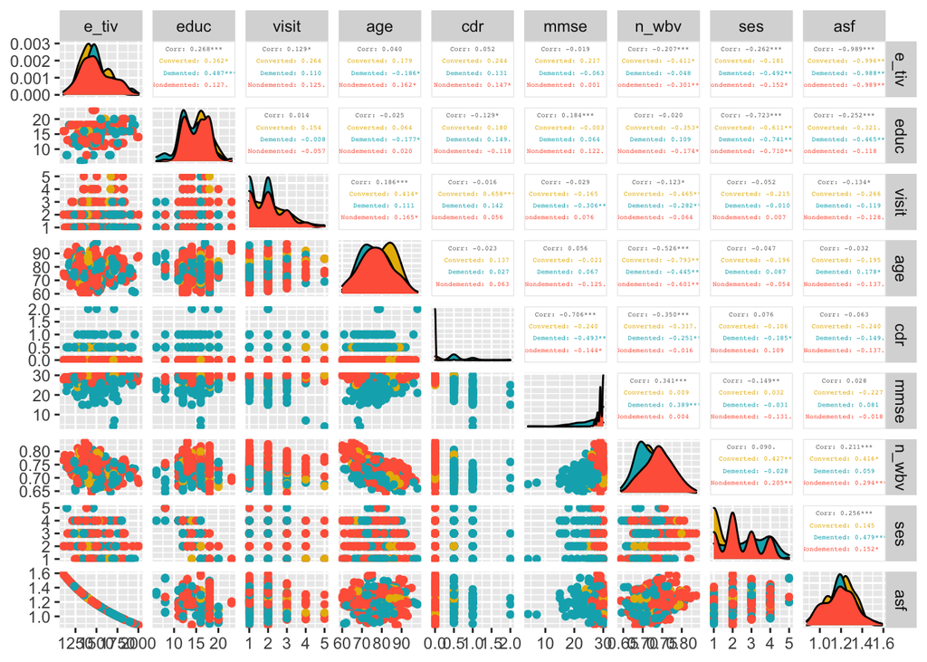

Figure 3.1: Pairwise plot matrix showing the correlations between variables. Yellow, blue and red indicate converted, demented and nondemented subjects respectively. Created with the package **GGally** and **ggplot2** (Schloerke et al. 2020; Hadley Wickham 2020).

## 3.2 Principal Components Analysis

### 3.2.1 Scree plot

A Scree plot was used to compare the sizes of the epigenvalues and determine the amount of components based on these sizes. Figure 3.2.1 uses the the data to examine how much variance each principal component accounts for through a percentage. The Scree plot shows PC1 explains roughly 30% of the explained variance. Principal components 6-9 explain less than 5% of the explained variance each.

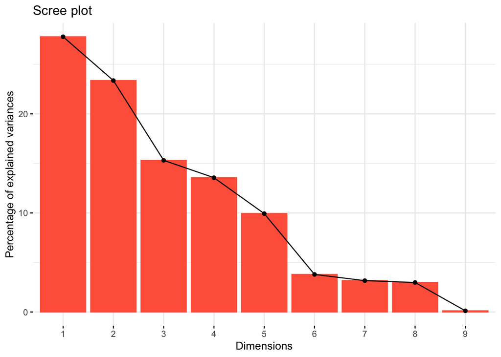

Figure 3.2.1: Scree plot showing the percentage of explanation of the Principal components. Created with the package **factoextra** (Alboukadel Kassambara 2020)

### 3.2.2 Variable Correlation Plot

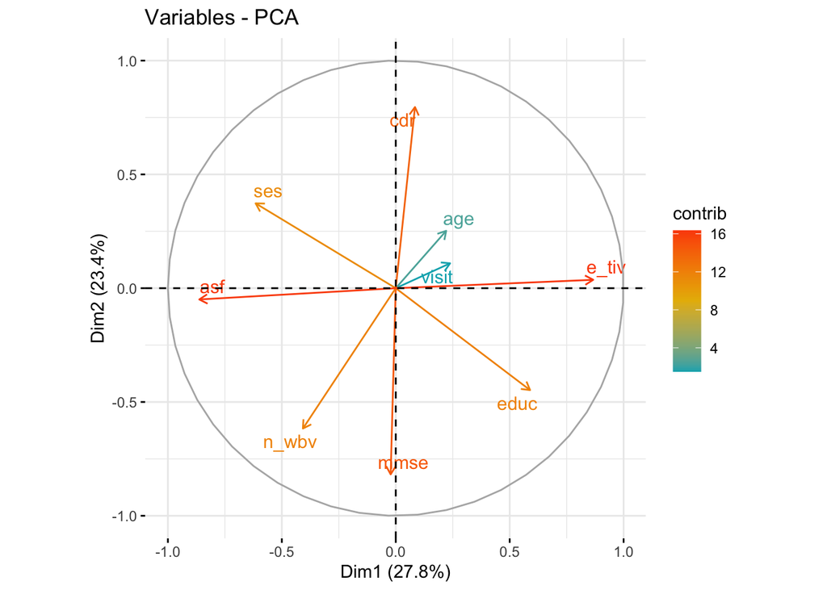

Figure 3.2.2: Plotting the variables of the PCA against PC1 and PC2. Colours indicate the degree of contribution of each variable on the principal component. Created with the package **factoextra** (Alboukadel Kassambara 2020)

### 3.2.3 Contribution Plot

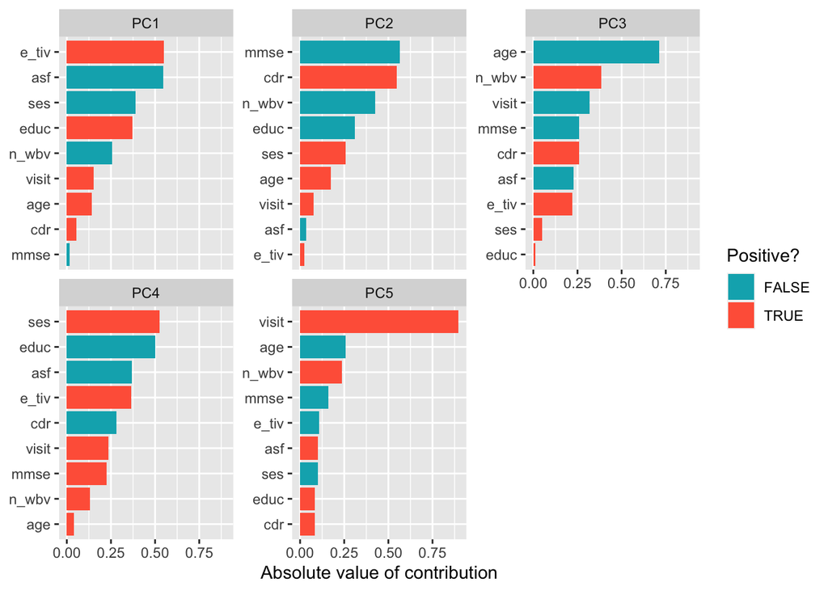

Figure 3.2.3: Plot showing the contribution of each variable on the Principal Components 1:5 which are known to explain the most variance within the data. Created with the package **tidytext** and **ggplot2** (Gabriela De Queiroz 2018; Hadley Wickham 2020).

### 3.2.4 A closer look into PC1, PC2 and PC3

I examined how the data is distributed in the plane of the first two components, PC1 and PC2. Below show biplots, a combination of a score plot overlaid by a loading plot. In *Figure 3.2.4.1*, along the dimension of PC2, demented subjects stand out compared to non-demented and converted where there is a significant amount of overlap. Clinical dementia rating is shown to be important in PC2, which agrees with the figures above. Looking at *Figure 3.2.4.2*, where PC2 is being compared to PC3, it presents similar conclusions to the previous, including large divergence of the subjects with dementia and clinical dementia rating being important in PC2. The gradient of the group categories follows the PC2 dimensions in both cases; this is probably the case due to clinical dementia rating being a large factor in PC2, and also correlating with the groups, so subjects who fall under the demented category will have a higher clinical dementia rating, followed by converted, then nondemented subjects.

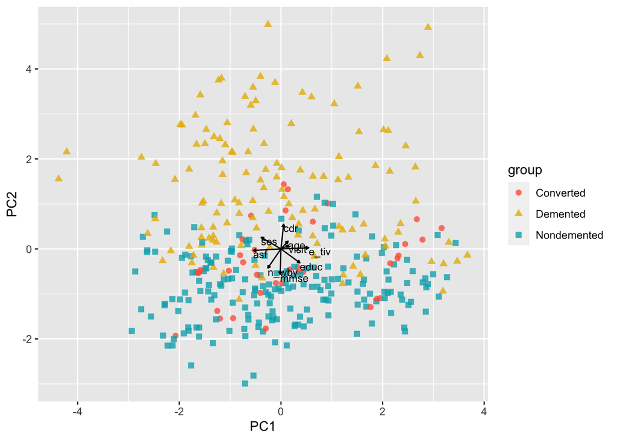

Figure 3.2.4.1: A biplot comparing Principal Components one and two. The different groups are separated out as indicated in the key. Created with the package **recipes** and **ggplot2** (H. W. Max Kuhn 2020; Hadley Wickham 2020).

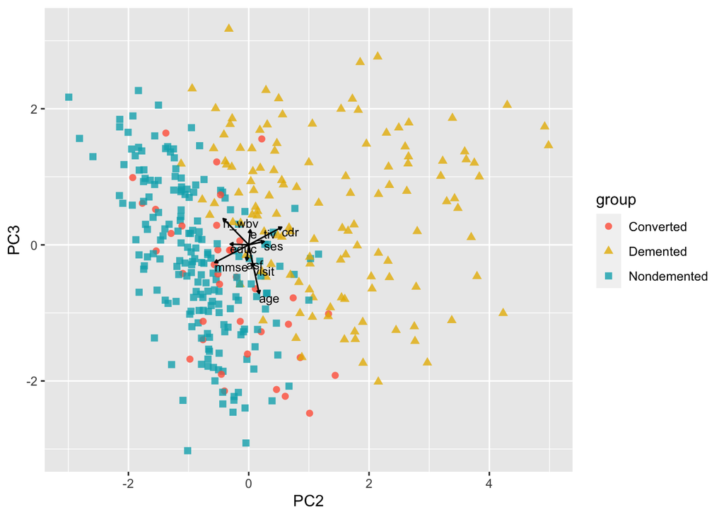

Figure 3.2.4.2: A biplot comparing Principal Components two and three. The different groups are separated out as indicated in the key. Created with the package **recipes** and **ggplot2** (H. W. Max Kuhn 2020; Hadley Wickham 2020).

## 3.3 Correlation matrix

The table in *Figure 3.3.1* shows the largest positive relationship between Mini-Mental State Examination score (mmse) and normalized whole-brain volume (n_wbv). I would have expected to see clinical dementia rating (cdr) having a larger effect on the other variables.

The network plot in *Figure 3.3.2* uses clustering to easily illustrate which variables are closer/ further apart from one another. Atlas scaling factor (asf) and estimated total intracranial volume (e_tiv) are in close proximity and appear to have a strong negative relationship. This can also been seen to a slightly weaker extent between years of education (educ) and socioeconomic status (ses).

| term | e_tiv | educ | visit | age | cdr | mmse | n_wbv | ses | asf |
| --- | --- | --- | --- | --- | --- | --- | --- | --- | --- |
| e_tiv | NA | 0.26793253 | 0.12874461 | 0.04018230 | 0.05236148 | -0.01943860 | -0.20666821 | -0.26157502 | -0.98902995 |
| educ | 0.26793253 | NA | 0.01357410 | -0.02497696 | -0.12943956 | 0.18445884 | -0.01982239 | -0.72264728 | -0.25167731 |
| visit | 0.12874461 | 0.01357410 | NA | 0.18630599 | -0.01554418 | -0.02903131 | -0.12345252 | -0.05162200 | -0.13389661 |
| age | 0.04018230 | -0.02497696 | 0.18630599 | NA | -0.02275853 | 0.05587955 | -0.52631645 | -0.04685671 | -0.03178258 |
| cdr | 0.05236148 | -0.12943956 | -0.01554418 | -0.02275853 | NA | -0.70596172 | -0.35008571 | 0.07615998 | -0.06341298 |
| mmse | -0.01943860 | 0.18445884 | -0.02903131 | 0.05587955 | -0.70596172 | NA | 0.34138102 | -0.14921871 | 0.02774469 |
| n_wbv | -0.20666821 | -0.01982239 | -0.12345252 | -0.52631645 | -0.35008571 | 0.34138102 | NA | 0.09009523 | 0.21114974 |
| ses | -0.26157502 | -0.72264728 | -0.05162200 | -0.04685671 | 0.07615998 | -0.14921871 | 0.09009523 | NA | 0.25557643 |
| asf | -0.98902995 | -0.25167731 | -0.13389661 | -0.03178258 | -0.06341298 | 0.02774469 | 0.21114974 | 0.25557643 | NA |

Figure 3.3.1: A table presenting the results from the correlation matrix. Created with the package **corrr** and **formattable** (J. C. Max Kuhn Simon Jackson 2020; Kun Ren 2021).

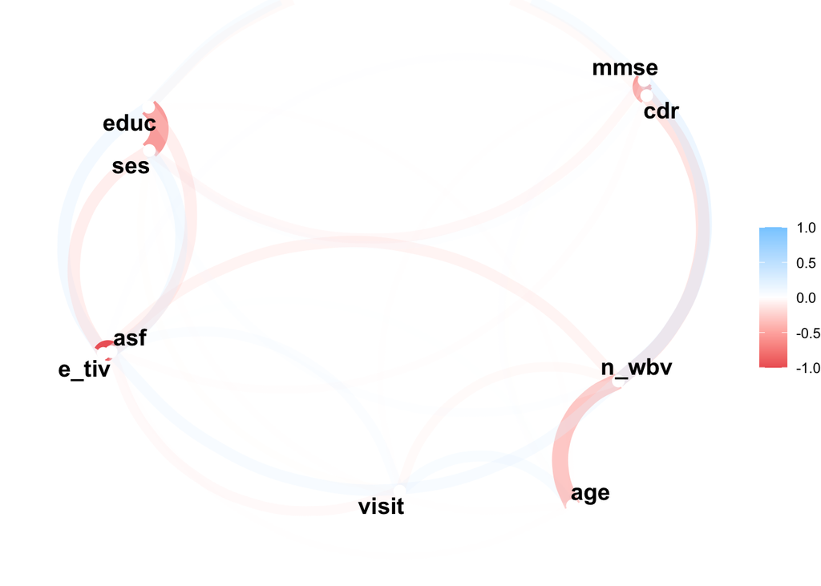

Figure 3.3.2: A network plot comparing the relationship and strenth between numerical variables. Strength of correlation displayed by the colour gradient. Created with the package **corrr** (J. C. Max Kuhn Simon Jackson 2020).

## Word count

This document: 2002  
README: 158  
**Total: 2160**

Calculated using wordcountaddin (Marwick, n.d.).

# References

Alboukadel Kassambara, Fabian Mundt. 2020. *Factoextra: Extract and Visualize the Results of Multivariate Data Analyses*. https://cran.r-project.org/web/packages/factoextra.

Allaire, JJ, Yihui Xie, Jonathan McPherson, Javier Luraschi, Kevin Ushey, Aron Atkins, Hadley Wickham, Joe Cheng, Winston Chang, and Richard Iannone. 2020. *Rmarkdown: Dynamic Documents for r*. https://github.com/rstudio/rmarkdown.

Bonifacio, Guendalina, and Giovanna Zamboni. 2016. “Brain Imaging in Dementia.” *Postgrad. Med. J.* 92 (1088): 333–40.

Cerejeira, J, L Lagarto, and E B Mukaetova-Ladinska. 2012. “Behavioral and Psychological Symptoms of Dementia.” *Front. Neurol.* 3 (May): 73.

Dening, Tom, and Malarvizhi Babu Sandilyan. 2015. “Dementia: Definitions and Types.” *Nurs. Stand.* 29 (37): 37–42.

Gabriela De Queiroz, Os Keyes, Emil Hvitfeldt. 2018. *Tidytext: Text Mining Using ’dplyr’, ’ggplot2’, and Other Tidy Tools*. https://cran.microsoft.com/snapshot/2018-06-12/web/packages/tidytext.

Hadley Wickham, Lionel Henry, Winston Chang. 2020. *Ggplot2: Create Elegant Data Visualisations Using the Grammar of Graphics*. https://cran.r-project.org/web/packages/ggplot2.

Kun Ren, Kenton Russell. 2021. *Formattable: Create ’formattable’ Data Structures*. https://cran.r-project.org/web/packages/formattable.

Marwick, Ben. n.d. “Wordcountaddin.” Github.

Max Kuhn, Hadley Wickham. 2020. *Recipes: Preprocessing Tools to Create Design Matrices*. https://cran.r-project.org/web/packages/recipes.

Max Kuhn, Jorge Cimentada, Simon Jackson. 2020. *Fcorrr: Correlations in r*. https://cran.r-project.org/web/packages/corrr.

R Core Team. 2020. *R: A Language and Environment for Statistical Computing*. Vienna, Austria: R Foundation for Statistical Computing. https://www.R-project.org/.

Schloerke, Barret, Di Cook, Joseph Larmarange, Francois Briatte, Moritz Marbach, Edwin Thoen, Amos Elberg, and Jason Crowley. 2020. *GGally: Extension to ’ggplot2’*. https://CRAN.R-project.org/package=GGally.

Shih, Regina A, Thomas W Concannon, Jodi L Liu, and Esther M Friedman. 2014. “Introduction.” In *Improving Dementia Long-Term Care*, 1–12. A Policy Blueprint. RAND Corporation.

Wickham, Hadley. 2019. *Tidyverse: Easily Install and Load the Tidyverse*. https://CRAN.R-project.org/package=tidyverse.

Wickham, Hadley, Romain François, Lionel Henry, and Kirill Müller. 2020. *Dplyr: A Grammar of Data Manipulation*. https://CRAN.R-project.org/package=dplyr.